# Risk Factor Analysis

## Outcome Variable

**Outcome Variable:** haz

## Predictor Variables

**Intervention Variable:** nhh

**Adjustment Set:**

- arm
- W_mage
- meducyrs
- feducyrs
- hhwealth_quart
- W_mhtcm
- W_mwtkg
- W_mbmi
- W_nrooms
- cleanck
- impfloor
- impsan
- safeh20
- delta_W_mage
- delta_meducyrs
- delta_feducyrs
- delta_hhwealth_quart
- delta_W_mhtcm
- delta_W_mwtkg
- delta_W_mbmi
- delta_W_nrooms
- delta_cleanck
- delta_impfloor
- delta_impsan
- delta_safeh20

## Stratifying Variables

The analysis was stratified on these variable(s):

- agecat
- studyid
- country

## Data Summary

| agecat | studyid | country | nhh | n_cell | n |
| --- | --- | --- | --- | --- | --- |
| Birth | ki1000108-IRC | INDIA | 3 or less | 54 | 388 |
| Birth | ki1000108-IRC | INDIA | 4-5 | 150 | 388 |
| Birth | ki1000108-IRC | INDIA | 6-7 | 103 | 388 |
| Birth | ki1000108-IRC | INDIA | 8+ | 81 | 388 |
| Birth | ki1017093-NIH-Birth | BANGLADESH | 3 or less | 112 | 608 |
| Birth | ki1017093-NIH-Birth | BANGLADESH | 4-5 | 255 | 608 |
| Birth | ki1017093-NIH-Birth | BANGLADESH | 6-7 | 138 | 608 |
| Birth | ki1017093-NIH-Birth | BANGLADESH | 8+ | 103 | 608 |
| Birth | ki1017093b-PROVIDE | BANGLADESH | 3 or less | 104 | 539 |
| Birth | ki1017093b-PROVIDE | BANGLADESH | 4-5 | 251 | 539 |
| Birth | ki1017093b-PROVIDE | BANGLADESH | 6-7 | 116 | 539 |
| Birth | ki1017093b-PROVIDE | BANGLADESH | 8+ | 68 | 539 |
| Birth | ki1017093c-NIH-Crypto | BANGLADESH | 3 or less | 108 | 732 |
| Birth | ki1017093c-NIH-Crypto | BANGLADESH | 4-5 | 328 | 732 |
| Birth | ki1017093c-NIH-Crypto | BANGLADESH | 6-7 | 176 | 732 |
| Birth | ki1017093c-NIH-Crypto | BANGLADESH | 8+ | 120 | 732 |
| 6 months | ki1000108-IRC | INDIA | 3 or less | 58 | 407 |
| 6 months | ki1000108-IRC | INDIA | 4-5 | 158 | 407 |
| 6 months | ki1000108-IRC | INDIA | 6-7 | 106 | 407 |
| 6 months | ki1000108-IRC | INDIA | 8+ | 85 | 407 |
| 6 months | ki1000304b-SAS-FoodSuppl | INDIA | 3 or less | 33 | 380 |
| 6 months | ki1000304b-SAS-FoodSuppl | INDIA | 4-5 | 166 | 380 |
| 6 months | ki1000304b-SAS-FoodSuppl | INDIA | 6-7 | 115 | 380 |
| 6 months | ki1000304b-SAS-FoodSuppl | INDIA | 8+ | 66 | 380 |
| 6 months | ki1017093-NIH-Birth | BANGLADESH | 3 or less | 95 | 537 |
| 6 months | ki1017093-NIH-Birth | BANGLADESH | 4-5 | 227 | 537 |
| 6 months | ki1017093-NIH-Birth | BANGLADESH | 6-7 | 128 | 537 |
| 6 months | ki1017093-NIH-Birth | BANGLADESH | 8+ | 87 | 537 |
| 6 months | ki1017093b-PROVIDE | BANGLADESH | 3 or less | 105 | 604 |
| 6 months | ki1017093b-PROVIDE | BANGLADESH | 4-5 | 289 | 604 |
| 6 months | ki1017093b-PROVIDE | BANGLADESH | 6-7 | 130 | 604 |
| 6 months | ki1017093b-PROVIDE | BANGLADESH | 8+ | 80 | 604 |
| 6 months | ki1017093c-NIH-Crypto | BANGLADESH | 3 or less | 104 | 715 |
| 6 months | ki1017093c-NIH-Crypto | BANGLADESH | 4-5 | 326 | 715 |
| 6 months | ki1017093c-NIH-Crypto | BANGLADESH | 6-7 | 170 | 715 |
| 6 months | ki1017093c-NIH-Crypto | BANGLADESH | 8+ | 115 | 715 |
| 6 months | ki1148112-LCNI-5 | MALAWI | 3 or less | 224 | 816 |
| 6 months | ki1148112-LCNI-5 | MALAWI | 4-5 | 340 | 816 |
| 6 months | ki1148112-LCNI-5 | MALAWI | 6-7 | 182 | 816 |
| 6 months | ki1148112-LCNI-5 | MALAWI | 8+ | 70 | 816 |
| 24 months | ki1000108-IRC | INDIA | 3 or less | 58 | 409 |
| 24 months | ki1000108-IRC | INDIA | 4-5 | 158 | 409 |
| 24 months | ki1000108-IRC | INDIA | 6-7 | 107 | 409 |
| 24 months | ki1000108-IRC | INDIA | 8+ | 86 | 409 |
| 24 months | ki1017093-NIH-Birth | BANGLADESH | 3 or less | 75 | 429 |
| 24 months | ki1017093-NIH-Birth | BANGLADESH | 4-5 | 184 | 429 |
| 24 months | ki1017093-NIH-Birth | BANGLADESH | 6-7 | 100 | 429 |
| 24 months | ki1017093-NIH-Birth | BANGLADESH | 8+ | 70 | 429 |
| 24 months | ki1017093b-PROVIDE | BANGLADESH | 3 or less | 106 | 578 |
| 24 months | ki1017093b-PROVIDE | BANGLADESH | 4-5 | 273 | 578 |
| 24 months | ki1017093b-PROVIDE | BANGLADESH | 6-7 | 117 | 578 |
| 24 months | ki1017093b-PROVIDE | BANGLADESH | 8+ | 82 | 578 |
| 24 months | ki1017093c-NIH-Crypto | BANGLADESH | 3 or less | 69 | 514 |
| 24 months | ki1017093c-NIH-Crypto | BANGLADESH | 4-5 | 232 | 514 |
| 24 months | ki1017093c-NIH-Crypto | BANGLADESH | 6-7 | 130 | 514 |
| 24 months | ki1017093c-NIH-Crypto | BANGLADESH | 8+ | 83 | 514 |
| 24 months | ki1148112-LCNI-5 | MALAWI | 3 or less | 159 | 574 |
| 24 months | ki1148112-LCNI-5 | MALAWI | 4-5 | 237 | 574 |
| 24 months | ki1148112-LCNI-5 | MALAWI | 6-7 | 129 | 574 |
| 24 months | ki1148112-LCNI-5 | MALAWI | 8+ | 49 | 574 |

The following strata were considered:

- agecat: 24 months, studyid: ki1000108-IRC, country: INDIA
- agecat: 24 months, studyid: ki1017093-NIH-Birth, country: BANGLADESH
- agecat: 24 months, studyid: ki1017093b-PROVIDE, country: BANGLADESH
- agecat: 24 months, studyid: ki1017093c-NIH-Crypto, country: BANGLADESH
- agecat: 24 months, studyid: ki1148112-LCNI-5, country: MALAWI
- agecat: 6 months, studyid: ki1000108-IRC, country: INDIA
- agecat: 6 months, studyid: ki1000304b-SAS-FoodSuppl, country: INDIA
- agecat: 6 months, studyid: ki1017093-NIH-Birth, country: BANGLADESH
- agecat: 6 months, studyid: ki1017093b-PROVIDE, country: BANGLADESH
- agecat: 6 months, studyid: ki1017093c-NIH-Crypto, country: BANGLADESH
- agecat: 6 months, studyid: ki1148112-LCNI-5, country: MALAWI
- agecat: Birth, studyid: ki1000108-IRC, country: INDIA
- agecat: Birth, studyid: ki1017093-NIH-Birth, country: BANGLADESH
- agecat: Birth, studyid: ki1017093b-PROVIDE, country: BANGLADESH
- agecat: Birth, studyid: ki1017093c-NIH-Crypto, country: BANGLADESH

## Methods Detail

We’re interested in the causal parameters $E[Y_a]$ for all values of $a \in \mathcal{A}$. These parameters represent the mean outcome if, possibly contrary to fact, we intervened to set all units to have $A=a$. Under the randomization and positivity assumptions, these are identified by the statistical parameters $\psi_a=E_W[E_{Y|A,W}(Y|A=a,W)]$. In addition, we’re interested in the mean of $Y$, $E[Y]$ under no intervention (the observed mean). We will estimate these parameters by using SuperLearner to fit the relevant likelihood factors – $E_{Y|A,W}(Y|A=a,W)$ and $p(A=a|W)$, and then updating our likelihood fit using a joint TMLE.

For unadjusted analyses ($W=\{\}$), initial likelihoods were estimated using Lrnr_glm to estimate the simple $E(Y|A)$ and Lrnr_mean to estimate $p(A)$. For adjusted analyses, a small library containing Lrnr_glmnet, Lrnr_xgboost, and Lrnr_mean was used.

Having estimated these parameters, we will then use the delta method to estimate relative risks and attributable risks relative to a prespecified baseline level of $A$.

# Results Detail

## Results Plots

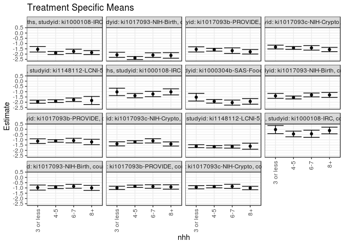

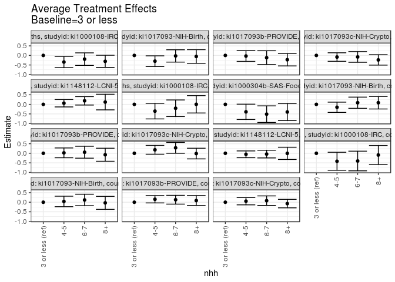

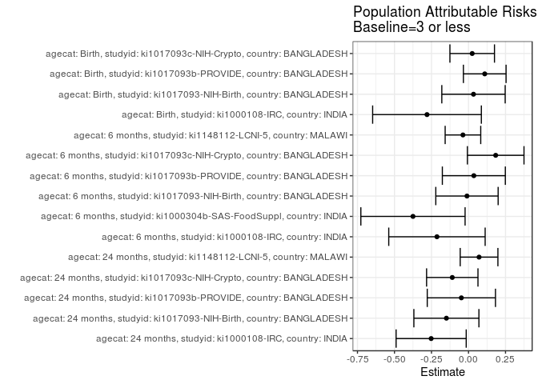

## Results Table

### Parameter: TSM

| agecat | studyid | country | intervention_level | baseline_level | estimate | ci_lower | ci_upper |
| --- | --- | --- | --- | --- | --- | --- | --- |
| Birth | ki1000108-IRC | INDIA | 3 or less | NA | -0.0276876 | -0.4132710 | 0.3578958 |
| Birth | ki1000108-IRC | INDIA | 4-5 | NA | -0.4450396 | -0.7153601 | -0.1747192 |
| Birth | ki1000108-IRC | INDIA | 6-7 | NA | -0.4304966 | -0.7693018 | -0.0916914 |
| Birth | ki1000108-IRC | INDIA | 8+ | NA | -0.1182310 | -0.4327995 | 0.1963376 |
| Birth | ki1017093-NIH-Birth | BANGLADESH | 3 or less | NA | -0.9647268 | -1.2047113 | -0.7247424 |
| Birth | ki1017093-NIH-Birth | BANGLADESH | 4-5 | NA | -0.9248500 | -1.0614924 | -0.7882076 |
| Birth | ki1017093-NIH-Birth | BANGLADESH | 6-7 | NA | -0.8461407 | -1.0283974 | -0.6638841 |
| Birth | ki1017093-NIH-Birth | BANGLADESH | 8+ | NA | -0.9982066 | -1.2373151 | -0.7590981 |
| Birth | ki1017093b-PROVIDE | BANGLADESH | 3 or less | NA | -0.9946865 | -1.1514097 | -0.8379632 |
| Birth | ki1017093b-PROVIDE | BANGLADESH | 4-5 | NA | -0.8410465 | -0.9523449 | -0.7297480 |
| Birth | ki1017093b-PROVIDE | BANGLADESH | 6-7 | NA | -0.8643703 | -1.0339599 | -0.6947806 |
| Birth | ki1017093b-PROVIDE | BANGLADESH | 8+ | NA | -0.9078690 | -1.1160327 | -0.6997053 |
| Birth | ki1017093c-NIH-Crypto | BANGLADESH | 3 or less | NA | -0.9344088 | -1.0879686 | -0.7808490 |
| Birth | ki1017093c-NIH-Crypto | BANGLADESH | 4-5 | NA | -0.8802546 | -0.9933578 | -0.7671514 |
| Birth | ki1017093c-NIH-Crypto | BANGLADESH | 6-7 | NA | -0.8540886 | -1.0507365 | -0.6574407 |
| Birth | ki1017093c-NIH-Crypto | BANGLADESH | 8+ | NA | -1.0066260 | -1.1673265 | -0.8459255 |
| 6 months | ki1000108-IRC | INDIA | 3 or less | NA | -1.0212604 | -1.3751886 | -0.6673323 |
| 6 months | ki1000108-IRC | INDIA | 4-5 | NA | -1.3758427 | -1.5821921 | -1.1694934 |
| 6 months | ki1000108-IRC | INDIA | 6-7 | NA | -1.2245796 | -1.4760992 | -0.9730601 |
| 6 months | ki1000108-IRC | INDIA | 8+ | NA | -1.0179657 | -1.3063157 | -0.7296156 |
| 6 months | ki1000304b-SAS-FoodSuppl | INDIA | 3 or less | NA | -1.5235550 | -1.8861696 | -1.1609403 |
| 6 months | ki1000304b-SAS-FoodSuppl | INDIA | 4-5 | NA | -1.9143275 | -2.0841025 | -1.7445526 |
| 6 months | ki1000304b-SAS-FoodSuppl | INDIA | 6-7 | NA | -2.0358117 | -2.2743593 | -1.7972640 |
| 6 months | ki1000304b-SAS-FoodSuppl | INDIA | 8+ | NA | -1.9221146 | -2.1867352 | -1.6574940 |
| 6 months | ki1017093-NIH-Birth | BANGLADESH | 3 or less | NA | -1.3970125 | -1.6295009 | -1.1645240 |
| 6 months | ki1017093-NIH-Birth | BANGLADESH | 4-5 | NA | -1.5493028 | -1.6838119 | -1.4147937 |
| 6 months | ki1017093-NIH-Birth | BANGLADESH | 6-7 | NA | -1.3113352 | -1.4919225 | -1.1307480 |
| 6 months | ki1017093-NIH-Birth | BANGLADESH | 8+ | NA | -1.3109993 | -1.5440516 | -1.0779471 |
| 6 months | ki1017093b-PROVIDE | BANGLADESH | 3 or less | NA | -1.1277524 | -1.3527618 | -0.9027429 |
| 6 months | ki1017093b-PROVIDE | BANGLADESH | 4-5 | NA | -1.1049982 | -1.2269290 | -0.9830675 |
| 6 months | ki1017093b-PROVIDE | BANGLADESH | 6-7 | NA | -1.0720595 | -1.2867913 | -0.8573276 |
| 6 months | ki1017093b-PROVIDE | BANGLADESH | 8+ | NA | -1.2041778 | -1.4611663 | -0.9471892 |
| 6 months | ki1017093c-NIH-Crypto | BANGLADESH | 3 or less | NA | -1.3822574 | -1.5787937 | -1.1857211 |
| 6 months | ki1017093c-NIH-Crypto | BANGLADESH | 4-5 | NA | -1.2003095 | -1.3195995 | -1.0810194 |
| 6 months | ki1017093c-NIH-Crypto | BANGLADESH | 6-7 | NA | -1.0966874 | -1.3020743 | -0.8913005 |
| 6 months | ki1017093c-NIH-Crypto | BANGLADESH | 8+ | NA | -1.3964555 | -1.5945082 | -1.1984027 |
| 6 months | ki1148112-LCNI-5 | MALAWI | 3 or less | NA | -1.6051280 | -1.7459916 | -1.4642643 |
| 6 months | ki1148112-LCNI-5 | MALAWI | 4-5 | NA | -1.6585133 | -1.7642734 | -1.5527533 |
| 6 months | ki1148112-LCNI-5 | MALAWI | 6-7 | NA | -1.6459647 | -1.7896126 | -1.5023168 |
| 6 months | ki1148112-LCNI-5 | MALAWI | 8+ | NA | -1.6083367 | -1.8956786 | -1.3209947 |
| 24 months | ki1000108-IRC | INDIA | 3 or less | NA | -1.5465055 | -1.8031036 | -1.2899074 |
| 24 months | ki1000108-IRC | INDIA | 4-5 | NA | -1.8927782 | -2.0369798 | -1.7485765 |
| 24 months | ki1000108-IRC | INDIA | 6-7 | NA | -1.7401734 | -1.9443959 | -1.5359509 |
| 24 months | ki1000108-IRC | INDIA | 8+ | NA | -1.8553257 | -2.0427578 | -1.6678935 |
| 24 months | ki1017093-NIH-Birth | BANGLADESH | 3 or less | NA | -2.0697056 | -2.3110309 | -1.8283802 |
| 24 months | ki1017093-NIH-Birth | BANGLADESH | 4-5 | NA | -2.3698428 | -2.5150817 | -2.2246040 |
| 24 months | ki1017093-NIH-Birth | BANGLADESH | 6-7 | NA | -2.0953114 | -2.3133410 | -1.8772818 |
| 24 months | ki1017093-NIH-Birth | BANGLADESH | 8+ | NA | -2.1244371 | -2.3896757 | -1.8591985 |
| 24 months | ki1017093b-PROVIDE | BANGLADESH | 3 or less | NA | -1.5541392 | -1.8000896 | -1.3081889 |
| 24 months | ki1017093b-PROVIDE | BANGLADESH | 4-5 | NA | -1.5869772 | -1.7224014 | -1.4515530 |
| 24 months | ki1017093b-PROVIDE | BANGLADESH | 6-7 | NA | -1.6713401 | -1.9366820 | -1.4059981 |
| 24 months | ki1017093b-PROVIDE | BANGLADESH | 8+ | NA | -1.7777451 | -1.9913742 | -1.5641159 |
| 24 months | ki1017093c-NIH-Crypto | BANGLADESH | 3 or less | NA | -1.3316661 | -1.5110104 | -1.1523217 |
| 24 months | ki1017093c-NIH-Crypto | BANGLADESH | 4-5 | NA | -1.4161079 | -1.5488445 | -1.2833713 |
| 24 months | ki1017093c-NIH-Crypto | BANGLADESH | 6-7 | NA | -1.4106075 | -1.6257373 | -1.1954776 |
| 24 months | ki1017093c-NIH-Crypto | BANGLADESH | 8+ | NA | -1.5660779 | -1.7718788 | -1.3602769 |
| 24 months | ki1148112-LCNI-5 | MALAWI | 3 or less | NA | -1.9535406 | -2.0993983 | -1.8076829 |
| 24 months | ki1148112-LCNI-5 | MALAWI | 4-5 | NA | -1.8935242 | -2.0219180 | -1.7651304 |
| 24 months | ki1148112-LCNI-5 | MALAWI | 6-7 | NA | -1.7682007 | -1.9341251 | -1.6022763 |
| 24 months | ki1148112-LCNI-5 | MALAWI | 8+ | NA | -1.8334981 | -2.2142293 | -1.4527669 |

### Parameter: E(Y)

| agecat | studyid | country | intervention_level | baseline_level | estimate | ci_lower | ci_upper |
| --- | --- | --- | --- | --- | --- | --- | --- |
| Birth | ki1000108-IRC | INDIA | NA | NA | -0.3080412 | -0.4687931 | -0.1472894 |
| Birth | ki1017093-NIH-Birth | BANGLADESH | NA | NA | -0.9310197 | -1.0197391 | -0.8423003 |
| Birth | ki1017093b-PROVIDE | BANGLADESH | NA | NA | -0.8851020 | -0.9601332 | -0.8100709 |
| Birth | ki1017093c-NIH-Crypto | BANGLADESH | NA | NA | -0.9094945 | -0.9809370 | -0.8380521 |
| 6 months | ki1000108-IRC | INDIA | NA | NA | -1.2344062 | -1.3658524 | -1.1029600 |
| 6 months | ki1000304b-SAS-FoodSuppl | INDIA | NA | NA | -1.8986842 | -2.0118892 | -1.7854792 |
| 6 months | ki1017093-NIH-Birth | BANGLADESH | NA | NA | -1.4073821 | -1.4960598 | -1.3187043 |
| 6 months | ki1017093b-PROVIDE | BANGLADESH | NA | NA | -1.0916915 | -1.1661176 | -1.0172654 |
| 6 months | ki1017093c-NIH-Crypto | BANGLADESH | NA | NA | -1.1986783 | -1.2700937 | -1.1272630 |
| 6 months | ki1148112-LCNI-5 | MALAWI | NA | NA | -1.6426961 | -1.7120603 | -1.5733318 |
| 24 months | ki1000108-IRC | INDIA | NA | NA | -1.7987775 | -1.8923914 | -1.7051636 |
| 24 months | ki1017093-NIH-Birth | BANGLADESH | NA | NA | -2.2190579 | -2.3217459 | -2.1163699 |
| 24 months | ki1017093b-PROVIDE | BANGLADESH | NA | NA | -1.6024221 | -1.6857420 | -1.5191023 |
| 24 months | ki1017093c-NIH-Crypto | BANGLADESH | NA | NA | -1.4412646 | -1.5249156 | -1.3576135 |
| 24 months | ki1148112-LCNI-5 | MALAWI | NA | NA | -1.8822648 | -1.9637218 | -1.8008078 |

### Parameter: ATE

| agecat | studyid | country | intervention_level | baseline_level | estimate | ci_lower | ci_upper |
| --- | --- | --- | --- | --- | --- | --- | --- |
| Birth | ki1000108-IRC | INDIA | 3 or less | 3 or less | 0.0000000 | 0.0000000 | 0.0000000 |
| Birth | ki1000108-IRC | INDIA | 4-5 | 3 or less | -0.4173520 | -0.8889240 | 0.0542199 |
| Birth | ki1000108-IRC | INDIA | 6-7 | 3 or less | -0.4028090 | -0.9167985 | 0.1111804 |
| Birth | ki1000108-IRC | INDIA | 8+ | 3 or less | -0.0905434 | -0.5886253 | 0.4075386 |
| Birth | ki1017093-NIH-Birth | BANGLADESH | 3 or less | 3 or less | 0.0000000 | 0.0000000 | 0.0000000 |
| Birth | ki1017093-NIH-Birth | BANGLADESH | 4-5 | 3 or less | 0.0398768 | -0.2345432 | 0.3142968 |
| Birth | ki1017093-NIH-Birth | BANGLADESH | 6-7 | 3 or less | 0.1185861 | -0.1805704 | 0.4177426 |
| Birth | ki1017093-NIH-Birth | BANGLADESH | 8+ | 3 or less | -0.0334798 | -0.3731923 | 0.3062328 |
| Birth | ki1017093b-PROVIDE | BANGLADESH | 3 or less | 3 or less | 0.0000000 | 0.0000000 | 0.0000000 |
| Birth | ki1017093b-PROVIDE | BANGLADESH | 4-5 | 3 or less | 0.1536400 | -0.0370102 | 0.3442902 |
| Birth | ki1017093b-PROVIDE | BANGLADESH | 6-7 | 3 or less | 0.1303162 | -0.0991163 | 0.3597487 |
| Birth | ki1017093b-PROVIDE | BANGLADESH | 8+ | 3 or less | 0.0868175 | -0.1726806 | 0.3463156 |
| Birth | ki1017093c-NIH-Crypto | BANGLADESH | 3 or less | 3 or less | 0.0000000 | 0.0000000 | 0.0000000 |
| Birth | ki1017093c-NIH-Crypto | BANGLADESH | 4-5 | 3 or less | 0.0541542 | -0.1367801 | 0.2450884 |
| Birth | ki1017093c-NIH-Crypto | BANGLADESH | 6-7 | 3 or less | 0.0803202 | -0.1692269 | 0.3298672 |
| Birth | ki1017093c-NIH-Crypto | BANGLADESH | 8+ | 3 or less | -0.0722172 | -0.2938971 | 0.1494627 |
| 6 months | ki1000108-IRC | INDIA | 3 or less | 3 or less | 0.0000000 | 0.0000000 | 0.0000000 |
| 6 months | ki1000108-IRC | INDIA | 4-5 | 3 or less | -0.3545823 | -0.7622185 | 0.0530539 |
| 6 months | ki1000108-IRC | INDIA | 6-7 | 3 or less | -0.2033192 | -0.6369933 | 0.2303549 |
| 6 months | ki1000108-IRC | INDIA | 8+ | 3 or less | 0.0032948 | -0.4504480 | 0.4570375 |
| 6 months | ki1000304b-SAS-FoodSuppl | INDIA | 3 or less | 3 or less | 0.0000000 | 0.0000000 | 0.0000000 |
| 6 months | ki1000304b-SAS-FoodSuppl | INDIA | 4-5 | 3 or less | -0.3907726 | -0.7910158 | 0.0094707 |
| 6 months | ki1000304b-SAS-FoodSuppl | INDIA | 6-7 | 3 or less | -0.5122567 | -0.9459965 | -0.0785169 |
| 6 months | ki1000304b-SAS-FoodSuppl | INDIA | 8+ | 3 or less | -0.3985596 | -0.8471210 | 0.0500018 |
| 6 months | ki1017093-NIH-Birth | BANGLADESH | 3 or less | 3 or less | 0.0000000 | 0.0000000 | 0.0000000 |
| 6 months | ki1017093-NIH-Birth | BANGLADESH | 4-5 | 3 or less | -0.1522903 | -0.4201411 | 0.1155604 |
| 6 months | ki1017093-NIH-Birth | BANGLADESH | 6-7 | 3 or less | 0.0856772 | -0.2070460 | 0.3784004 |
| 6 months | ki1017093-NIH-Birth | BANGLADESH | 8+ | 3 or less | 0.0860131 | -0.2420237 | 0.4140500 |
| 6 months | ki1017093b-PROVIDE | BANGLADESH | 3 or less | 3 or less | 0.0000000 | 0.0000000 | 0.0000000 |
| 6 months | ki1017093b-PROVIDE | BANGLADESH | 4-5 | 3 or less | 0.0227541 | -0.2332871 | 0.2787953 |
| 6 months | ki1017093b-PROVIDE | BANGLADESH | 6-7 | 3 or less | 0.0556929 | -0.2550698 | 0.3664556 |
| 6 months | ki1017093b-PROVIDE | BANGLADESH | 8+ | 3 or less | -0.0764254 | -0.4176225 | 0.2647717 |
| 6 months | ki1017093c-NIH-Crypto | BANGLADESH | 3 or less | 3 or less | 0.0000000 | 0.0000000 | 0.0000000 |
| 6 months | ki1017093c-NIH-Crypto | BANGLADESH | 4-5 | 3 or less | 0.1819479 | -0.0481259 | 0.4120217 |
| 6 months | ki1017093c-NIH-Crypto | BANGLADESH | 6-7 | 3 or less | 0.2855699 | 0.0008605 | 0.5702794 |
| 6 months | ki1017093c-NIH-Crypto | BANGLADESH | 8+ | 3 or less | -0.0141981 | -0.2935214 | 0.2651251 |
| 6 months | ki1148112-LCNI-5 | MALAWI | 3 or less | 3 or less | 0.0000000 | 0.0000000 | 0.0000000 |
| 6 months | ki1148112-LCNI-5 | MALAWI | 4-5 | 3 or less | -0.0533853 | -0.2296088 | 0.1228382 |
| 6 months | ki1148112-LCNI-5 | MALAWI | 6-7 | 3 or less | -0.0408367 | -0.2420333 | 0.1603599 |
| 6 months | ki1148112-LCNI-5 | MALAWI | 8+ | 3 or less | -0.0032087 | -0.3233461 | 0.3169287 |
| 24 months | ki1000108-IRC | INDIA | 3 or less | 3 or less | 0.0000000 | 0.0000000 | 0.0000000 |
| 24 months | ki1000108-IRC | INDIA | 4-5 | 3 or less | -0.3462726 | -0.6406942 | -0.0518511 |
| 24 months | ki1000108-IRC | INDIA | 6-7 | 3 or less | -0.1936679 | -0.5216098 | 0.1342740 |
| 24 months | ki1000108-IRC | INDIA | 8+ | 3 or less | -0.3088202 | -0.6266674 | 0.0090270 |
| 24 months | ki1017093-NIH-Birth | BANGLADESH | 3 or less | 3 or less | 0.0000000 | 0.0000000 | 0.0000000 |
| 24 months | ki1017093-NIH-Birth | BANGLADESH | 4-5 | 3 or less | -0.3001373 | -0.5795370 | -0.0207375 |
| 24 months | ki1017093-NIH-Birth | BANGLADESH | 6-7 | 3 or less | -0.0256059 | -0.3486824 | 0.2974707 |
| 24 months | ki1017093-NIH-Birth | BANGLADESH | 8+ | 3 or less | -0.0547315 | -0.4121896 | 0.3027265 |
| 24 months | ki1017093b-PROVIDE | BANGLADESH | 3 or less | 3 or less | 0.0000000 | 0.0000000 | 0.0000000 |
| 24 months | ki1017093b-PROVIDE | BANGLADESH | 4-5 | 3 or less | -0.0328380 | -0.3133401 | 0.2476641 |
| 24 months | ki1017093b-PROVIDE | BANGLADESH | 6-7 | 3 or less | -0.1172008 | -0.4788075 | 0.2444059 |
| 24 months | ki1017093b-PROVIDE | BANGLADESH | 8+ | 3 or less | -0.2236058 | -0.5488502 | 0.1016386 |
| 24 months | ki1017093c-NIH-Crypto | BANGLADESH | 3 or less | 3 or less | 0.0000000 | 0.0000000 | 0.0000000 |
| 24 months | ki1017093c-NIH-Crypto | BANGLADESH | 4-5 | 3 or less | -0.0844419 | -0.3074126 | 0.1385289 |
| 24 months | ki1017093c-NIH-Crypto | BANGLADESH | 6-7 | 3 or less | -0.0789414 | -0.3584030 | 0.2005202 |
| 24 months | ki1017093c-NIH-Crypto | BANGLADESH | 8+ | 3 or less | -0.2344118 | -0.5071335 | 0.0383098 |
| 24 months | ki1148112-LCNI-5 | MALAWI | 3 or less | 3 or less | 0.0000000 | 0.0000000 | 0.0000000 |
| 24 months | ki1148112-LCNI-5 | MALAWI | 4-5 | 3 or less | 0.0600164 | -0.1343972 | 0.2544301 |
| 24 months | ki1148112-LCNI-5 | MALAWI | 6-7 | 3 or less | 0.1853399 | -0.0356616 | 0.4063414 |
| 24 months | ki1148112-LCNI-5 | MALAWI | 8+ | 3 or less | 0.1200425 | -0.2876576 | 0.5277426 |

### Parameter: PAR

| agecat | studyid | country | intervention_level | baseline_level | estimate | ci_lower | ci_upper |
| --- | --- | --- | --- | --- | --- | --- | --- |
| Birth | ki1000108-IRC | INDIA | 3 or less | NA | -0.2803536 | -0.6474944 | 0.0867871 |
| Birth | ki1017093-NIH-Birth | BANGLADESH | 3 or less | NA | 0.0337071 | -0.1803294 | 0.2477435 |
| Birth | ki1017093b-PROVIDE | BANGLADESH | 3 or less | NA | 0.1095844 | -0.0345003 | 0.2536691 |
| Birth | ki1017093c-NIH-Crypto | BANGLADESH | 3 or less | NA | 0.0249143 | -0.1255793 | 0.1754078 |
| 6 months | ki1000108-IRC | INDIA | 3 or less | NA | -0.2131458 | -0.5387161 | 0.1124245 |
| 6 months | ki1000304b-SAS-FoodSuppl | INDIA | 3 or less | NA | -0.3751292 | -0.7271793 | -0.0230792 |
| 6 months | ki1017093-NIH-Birth | BANGLADESH | 3 or less | NA | -0.0103696 | -0.2209163 | 0.2001771 |
| 6 months | ki1017093b-PROVIDE | BANGLADESH | 3 or less | NA | 0.0360609 | -0.1766936 | 0.2488153 |
| 6 months | ki1017093c-NIH-Crypto | BANGLADESH | 3 or less | NA | 0.1835790 | -0.0076253 | 0.3747834 |
| 6 months | ki1148112-LCNI-5 | MALAWI | 3 or less | NA | -0.0375681 | -0.1577132 | 0.0825770 |
| 24 months | ki1000108-IRC | INDIA | 3 or less | NA | -0.2522720 | -0.4890472 | -0.0154968 |
| 24 months | ki1017093-NIH-Birth | BANGLADESH | 3 or less | NA | -0.1493523 | -0.3690413 | 0.0703367 |
| 24 months | ki1017093b-PROVIDE | BANGLADESH | 3 or less | NA | -0.0482829 | -0.2786792 | 0.1821134 |
| 24 months | ki1017093c-NIH-Crypto | BANGLADESH | 3 or less | NA | -0.1095985 | -0.2831188 | 0.0639217 |
| 24 months | ki1148112-LCNI-5 | MALAWI | 3 or less | NA | 0.0712758 | -0.0560434 | 0.1985949 |